# Tutorial 13 — Advanced Features and Customisation

**Prerequisites:** Tutorials 01–12

This final tutorial covers the remaining public API surface: extension points for non-standard biology, convenience tools for model introspection, and features that fit most naturally after understanding the full model.

## 1 Imports

```python
import warnings

import numpy as np
import matplotlib.pyplot as plt

from pbisim import (ModelBuilder, PBIModel, solve_ode,
                    CONSTANT, LOGISTIC, MONOD, MONOD_LOGISTIC, ALL_PRESETS,
                    apply_preset, show_equations, get_parameters,
                    DoseEvent, DoseSchedule,
                    InitialConditions, stationary_phase_ic)
from pbisim.strains import BinaryResistanceGenotypes, BacterialStrain, PhageStrain
```

## 2 Superinfection — phage adsorption to infected bacteria

By default, phage only adsorb to **active uninfected** bacteria (B) and **dormant uninfected** bacteria (D). Once a bacterium is infected (I or H), it is shielded from secondary phage infection — a simplification based on the concept of **superinfection exclusion** (where the first infecting phage blocks subsequent ones).

Setting `allow_superinfection=True` removes this shield: phage can also adsorb to I and H compartments. This is biologically relevant when:

- Modelling **phage cocktails** where genetic recombination between co-infecting phages generates novel variants (directed evolution)
- Studying **lytic–lysogenic switching** where double infection affects fate
- Benchmarking against experimental data that shows phage loss beyond what B + D adsorption alone can explain

The secondary adsorption depletes the free-phage pool but does NOT create a new infected compartment (host fate is unchanged for simplicity).

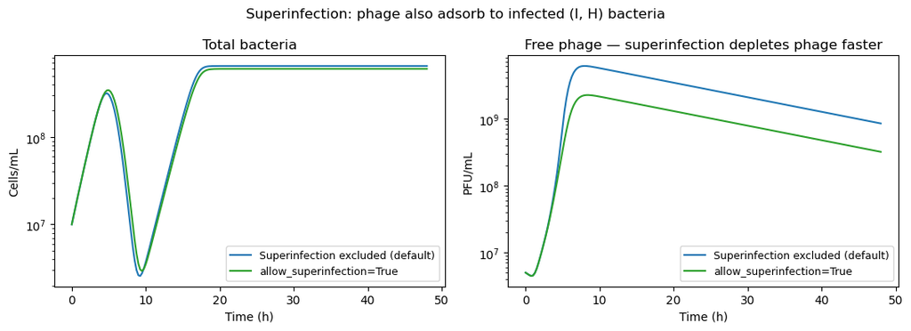

```python
# Two-strain model: strain 0 is phage-susceptible (adsorption=1e-8),
# strain 1 is phage-resistant (adsorption=0).  With superinfection enabled,
# phage also adsorb to already-infected I/H bacteria, depleting the phage
# pool faster — especially visible when many bacteria are in the infected state.
base_si = (
    ModelBuilder(n_bacteria=2, n_phages=1, n_latent=5)
    .with_growth_rates([1.2, 1.15], bacteria_to_resource_ratio=1e9)
    .with_phage_params(adsorption_rates=[1e-8, 0], burst_sizes=20.0,
                       latent_periods=2, phage_decay_rates=0.05)
    .with_nutrient(monod_constant=0.3, recycle_fraction=0.0)
    .with_dose_schedule(DoseSchedule([
        DoseEvent(time=0, amount=5e6, target="phage", index=0)
    ]))
)

fig, axes = plt.subplots(1, 2, figsize=(11, 4))
for (si, color, label) in [
    (False, "C0", "Superinfection excluded (default)"),
    (True,  "C2", "allow_superinfection=True"),
]:
    cfg = base_si.with_phage_params(allow_superinfection=si).build()
    res = solve_ode(
        PBIModel(cfg, initial_B=np.array([1e7, 1e3]),
                 initial_P=np.array([0.0]), initial_S=1.0),
        t_end=48.0, dt=0.25,
    )
    axes[0].semilogy(res.time,
                     np.maximum(res.sum_prefixes("B","D","I","H"), 1),
                     color=color, label=label)
    axes[1].semilogy(res.time, np.maximum(res.get("P0"), 1),
                     color=color, label=label)

axes[0].set(xlabel="Time (h)", ylabel="Cells/mL", title="Total bacteria")
axes[1].set(xlabel="Time (h)", ylabel="PFU/mL",
            title="Free phage — superinfection depletes phage faster")
for ax in axes: ax.legend(fontsize=9)
plt.suptitle("Superinfection: phage also adsorb to infected (I, H) bacteria")
plt.tight_layout()
plt.show()
```

## 3 Dynamic transition function — phage-pressure-induced resistance switching

`with_transition_function(fn)` adds a **state-dependent** phenotypic switch on top of the static `transition_rates` matrix. The function is evaluated at every ODE time step and its output is ADDED to the static matrix.

**Biological application:** phage stress triggers upregulation of resistance mechanisms in some bacteria (e.g., CRISPR adaptation, OM protein downregulation). When phage density is high, susceptible bacteria switch faster to a resistant phenotype.

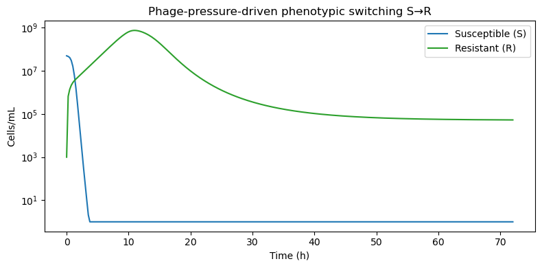

```python
def phage_driven_switch(S, B, P, config):
    # Phage-pressure-dependent rate of switching susceptible -> resistant
    n = config.n_bacteria
    m = config.n_phages
    phage_pressure = float(np.sum(P)) / (1e6 + float(np.sum(P)))  # saturating signal
    k_switch = 0.05 * phage_pressure   # max switching rate 0.05 h^-1
    T = np.zeros((n, n))
    if n >= 2:
        T[1, 0] =  k_switch   # S -> R rate increases with phage
        T[0, 0] = -k_switch   # S loses bacteria at same rate
    return T

cfg_switch = (
    ModelBuilder(n_bacteria=2, n_phages=1, n_latent=5)
    .with_growth_rates([1.0, 0.92])
    .with_phage_params(
        adsorption_rates=np.array([[2e-9], [2e-11]]),
        adsorption_rates_dormant=np.array([[2e-11], [2e-13]]),
        burst_sizes=50.0, latent_periods=0.5, phage_decay_rates=0.1,
    )
    .with_transition_function(phage_driven_switch)  # dynamic switch
    .with_nutrient(monod_constant=0.3, recycle_fraction=0.0)
    .with_dose_schedule(DoseSchedule([
        DoseEvent(time=0, amount=5e8, target="phage", index=0)
    ]))
    .build()
)

res_switch = solve_ode(
    PBIModel(cfg_switch, initial_B=np.array([5e7, 1e3]),
             initial_P=np.array([0.0]), initial_S=1.0),
    t_end=72.0, dt=0.25,
)

fig, ax = plt.subplots(figsize=(8, 4))
for i, (label, color) in enumerate([("Susceptible (S)", "C0"),
                                     ("Resistant (R)",   "C2")]):
    ax.semilogy(res_switch.time, np.maximum(res_switch.get(f"B{i}"), 1),
                color=color, label=label)
ax.set(xlabel="Time (h)", ylabel="Cells/mL",
       title="Phage-pressure-driven phenotypic switching S→R")
ax.legend()
plt.tight_layout()
plt.show()
```

## 4 Growth/dormancy presets

Presets bundle a consistent set of growth, dormancy, and resuscitation functions so you do not need to manually verify their compatibility.

| Preset | Growth | Dormancy trigger | `track_nutrients` |
| --- | --- | --- | --- |
| `CONSTANT` | Constant (no limit) | Constant rate | **False** |
| `LOGISTIC` | Logistic (density) | Density-dependent | **False** |
| `MONOD` | Monod (nutrient) | Nutrient-dependent | **True** |
| `MONOD_LOGISTIC` | Monod × logistic | Nutrient + density | **True** |

`apply_preset(cfg, preset)` returns a new `ModelConfig` with the preset's functions applied. It also sets `track_nutrients` correctly.

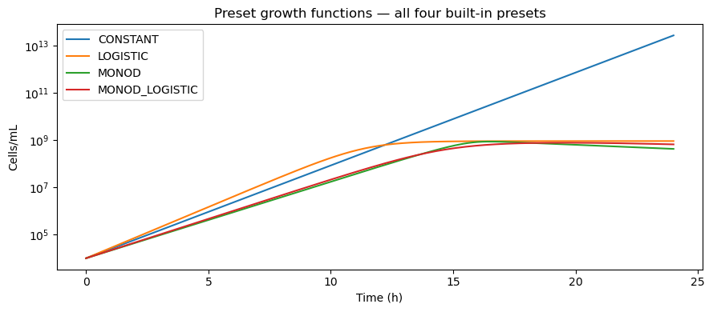

```python
presets = [CONSTANT, LOGISTIC, MONOD, MONOD_LOGISTIC]
labels  = ["CONSTANT", "LOGISTIC", "MONOD", "MONOD_LOGISTIC"]

fig, ax = plt.subplots(figsize=(9, 4))

for preset, label, color in zip(presets, labels, ["C0","C1","C2","C3"]):
    # Start from a minimal config
    kw = {"carrying_capacity": 1e9} if label in ("LOGISTIC","MONOD_LOGISTIC") else {}
    cfg_p = (
        ModelBuilder(n_bacteria=1, n_phages=0)
        .with_growth_rates(1.0, bacteria_to_resource_ratio=1e9)
        .with_dormancy(dormancy_rate=0.1, resuscitation_rate=0.05)
        .with_nutrient(monod_constant=0.3, **kw,
                       track_nutrients=preset in (MONOD, MONOD_LOGISTIC))
        .build()
    )
    cfg_p = apply_preset(cfg_p, preset)
    res_p = solve_ode(
        PBIModel(cfg_p, initial_B=np.array([1e4]),
                 initial_P=np.zeros(0), initial_S=1.0),
        t_end=24.0, dt=0.1,
    )
    ax.semilogy(res_p.time, np.maximum(res_p.get("B0"), 1),
                color=color, label=label)

ax.set(xlabel="Time (h)", ylabel="Cells/mL",
       title="Preset growth functions — all four built-in presets")
ax.legend()
plt.tight_layout()
plt.show()
```

## 5 `show_equations` and `get_parameters` — model introspection

Two tools help you verify that the model you built is what you intended:

- **`model.show_equations()`**: renders the full ODE system as LaTeX in Jupyter, or prints raw LaTeX in a terminal. Flags which features are active (phage PK, dormancy, antibiotic PD, etc.).
- **`model.get_parameters()`**: returns all current parameter values as a flat dictionary — useful for sanity-checking that broadcasting and defaults worked correctly before a long simulation run.

```python
# Build a model with several features active
cfg_inspect = (
    ModelBuilder(n_bacteria=2, n_phages=1, n_latent=3, n_depth=2)
    .with_growth_rates([1.0, 0.93], bacteria_to_resource_ratio=1e9)
    .with_phage_params(adsorption_rates=np.array([[2e-9],[2e-11]]),
                       burst_sizes=50.0, latent_periods=0.5,
                       phage_decay_rates=0.1)
    .with_dormancy(dormancy_rate=0.1, resuscitation_rate=0.05,
                   dormancy_signal="nutrient", resuscitation_signal="nutrient")
    .with_immunity(immune_module="innate", imm_stim_rate=1.0,
                   imm_kill_rate=3e6, imm_decay_rate=0.15,
                   imm_stim50=5e6, imm_kill50=5e6)
    .with_mutations(phage_resistance_rates=[5e-8])
    .with_nutrient(monod_constant=0.3, recycle_fraction=0.3)
    .build()
)
model_inspect = PBIModel(cfg_inspect,
                          initial_B=np.array([5e7, 1e2]),
                          initial_P=np.array([0.0]), initial_S=1.0)

# Print a subset of parameters (full dict is long)
params = model_inspect.get_parameters()
keys_to_show = ["growth_rates", "adsorption_rates", "burst_sizes",
                "mutation_rates", "dormancy_rate", "imm_kill_rate",
                "recycle_fraction"]
print("Key model parameters:")
for k in keys_to_show:
    print(f"  {k}: {params[k]}")

# In Jupyter this renders LaTeX; in terminal it prints the source
print("\nODE system (plain text — renders as LaTeX in Jupyter):")
model_inspect.show_equations(plain=True)
```

```
Key model parameters:
  growth_rates: [1.   0.93]
  adsorption_rates: [[2.e-09]
 [2.e-11]]
  burst_sizes: [[50.]
 [50.]]
  mutation_rates: [[-5.e-08  0.e+00]
 [ 5.e-08  0.e+00]]
  dormancy_rate: [0.1 0.1]
  imm_kill_rate: [3000000. 3000000.]
  recycle_fraction: 0.3

ODE system (plain text — renders as LaTeX in Jupyter):
────────────────────────────────────────────────────────────────────────
PBIModel — 2 strains, 1 phage
Active: Monod growth, dormancy (Q=2), innate immunity
────────────────────────────────────────────────────────────────────────

ODE System (LaTeX source):

\begin{aligned}
  \dfrac{dB_i}{dt} &= \mu_i\,f(S)\,B_i && \text{\small growth} \\
    &\quad +\; \textstyle\sum_k M_{ik}\,B_k && \text{\small mutations from/to other strains} \\
    &\quad -\; \varphi_i\,B_i && \text{\small entry into dormancy} \\
    &\quad +\; \rho_i\,D_{0,i} && \text{\small resuscitation} \\
    &\quad -\; \textstyle\sum_j \beta_{ij}\,P_j\,B_i && \text{\small phage adsorption} \\
    &\quad -\; \frac{\kappa_i\,\mathrm{Imm}\,B_i}{K_\mathrm{kill}+B_\mathrm{tot}} && \text{\small immune killing} \\\\
  \dfrac{dP_j}{dt} &= \textstyle\sum_i N_{ij}\,\gamma_{ij}\,I_{3,i,j}\,\phi && \text{\small burst lysis from active infected (last latent stage)} \\
    &\quad +\; \textstyle\sum_{d,i} N_{ij}\,\gamma_{ij}^D\,H_{d,3,i,j}\,\phi && \text{\small burst lysis from hibernating bacteria} \\
    &\quad -\; \textstyle\sum_i \beta_{ij}\,B_i\,P_j && \text{\small adsorption to active bacteria} \\
    &\quad -\; \textstyle\sum_{d,i}\beta_{ij}^D e^{-\alpha_{ij}d}\,D_{d,i}\,P_j && \text{\small adsorption to dormant bacteria} \\
    &\quad -\; \delta_j\,P_j && \text{\small phage decay} \\\\
  \dfrac{dI_{l,i,j}}{dt} &= \beta_{ij}\,B_i\,P_j\;\mathbf{1}_{[l=1]} && \text{\small new infection (first stage only)} \\
    &\quad -\; \gamma_{ij}\,I_{l,i,j}\,\phi && \text{\small progression / lysis at last stage} \\
    &\quad +\; \gamma_{ij}\,I_{l-1,i,j}\,\phi\;\mathbf{1}_{[l>1]} && \text{\small arrival from previous stage} \\
    &\quad -\; \varphi_i\,I_{l,i,j} && \text{\small dormancy entry} \\
    &\quad +\; \rho_i\,H_{0,l,i,j} && \text{\small resuscitation from hibernation} \\
    &\quad -\; \frac{\kappa_i\,\mathrm{Imm}\,I_{l,i,j}}{K_\mathrm{kill}+B_\mathrm{tot}} && \text{\small immune killing} \\\\
  \dfrac{dD_{d,i}}{dt} &= \varphi_i\,B_i\;\mathbf{1}_{[d=1]} && \text{\small dormancy entry (surface layer)} \\
    &\quad -\; \rho_i\,D_{0,i}\;\mathbf{1}_{[d=1]} && \text{\small resuscitation (surface layer only)} \\
```

[output cut: 28 more lines]

```
  \delta_j                        phage decay / clearance rate (h⁻¹)
  \phi                            lysis progression signal (= f(S) by default)
  \varphi_i                       dormancy entry rate (h⁻¹)
  \rho_i                          resuscitation rate (h⁻¹)
  \xi_i                           dormancy-depth diffusion rate constant (h⁻¹)
  f_S                             nutrient signal for depth diffusion = S / (K_s + S)
  \beta_{ij}^D                    adsorption rate to dormant bacteria
  \alpha_{ij}                     depth attenuation of phage penetration
  \sigma_i                        immune stimulation rate per bacterium
  \kappa_i                        immune kill rate coefficient
  K_\mathrm{stim}                 immune stimulation half-sat. = 5e+06
  K_\mathrm{kill}                 immune killing half-sat. = 5e+06
  \delta_\mathrm{{Imm}}           immune effector decay rate = 0.15
  \eta                            biomass recycle fraction = 0.3
────────────────────────────────────────────────────────────────────────
```

[output not shown]

## 6 OD measurement — bacterial debris ODE

In a **colony-forming unit (CFU)** assay, only viable bacteria produce colonies, so lysed bacteria disappear from the readout immediately. In an **optical density (OD)** assay, the spectrophotometer counts *all* light-scattering particles, including the membrane fragments and protein aggregates left behind when bacteria die or are lysed. This means:

- **Natural death and antibiotic killing** leave behind ghost cells that scatter almost as much light as live cells (at least for a few hours).
- **Phage lysis** bursts the cell open, releasing smaller fragments that scatter *less* light per event than an intact dead cell.

As a result, **phage-induced killing is systematically underestimated by OD** relative to CFU — a well-known experimental artefact.

### The debris ODE

Calling `.with_od_debris(u, v, kdis)` on the builder adds a single extra state variable `Debris` with the ODE:

$$\frac{d\,\text{Debris}}{dt} = \underbrace{u \cdot \text{(natural + antibiotic deaths)}}_{\text{intact debris}} + \underbrace{v \cdot \text{(phage lysis)}}_{\text{lysis fragments}} - k_\text{dis} \cdot \text{Debris}$$

Immune killing (phagocytosis) is **excluded**: engulfed bacteria do not release debris into the medium.

| Parameter | Meaning | Typical range |
| --- | --- | --- |
| `u` | Scattering weight of non-lysis debris (natural + antibiotic death) | 0.5 – 1.0 |
| `v` | Scattering weight of lysis fragments | 0.1 – 0.5 |
| `kdis` | Debris dissolution / sedimentation rate (h⁻¹) | 0 – 0.1 |
| `od_to_cfu_conversion_factor` | Converts CFU-scale units to true OD (AU): `OD = (Btot + Debris) / factor` | ~10⁸–10⁹ CFU/OD₆₀₀ |

OD is then accessed via `result.get_od()`. With the default factor of 1.0 the result is in CFU/mL units. Set `od_to_cfu_conversion_factor` to your organism's empirical conversion (e.g. ~8×10⁸ CFU/mL per OD₆₀₀ unit for *E. coli*) to get true absorbance values.

> **Note:** combining `with_od_debris()` with active immune killing emits a `UserWarning` at model construction, flagging the in vitro / in vivo mismatch.

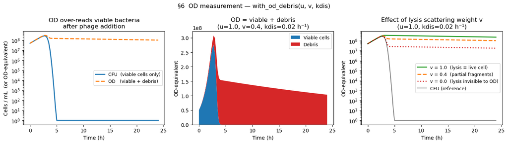

```
  Time (h)      CFU (cells/mL)     OD-equivalent          Debris
------------------------------------------------------------------
         4            7.58e+05          1.55e+08        1.54e+08
         8            0.00e+00          1.42e+08        1.42e+08
        12            0.00e+00          1.31e+08        1.31e+08
        18            0.00e+00          1.16e+08        1.16e+08
        24            0.00e+00          1.03e+08        1.03e+08

At late times CFU→0 but OD persists due to debris.
This is the OD/CFU discrepancy that with_od_debris() models.
```

```python
# ── Shared base: a single-strain phage-killing experiment ────────────────────
# Natural death (5% h⁻¹) provides the u-path debris; phage lysis provides v-path.
# No immune module → no UserWarning when debris is enabled.
base_od = (
    ModelBuilder(n_bacteria=1, n_phages=1, n_latent=10)
    .with_growth_rates(1.0, bacteria_to_resource_ratio=1e9)
    .with_phage_params(adsorption_rates=2e-9, burst_sizes=50.0,
                       latent_periods=0.5, phage_decay_rates=0.05)
    .with_death(death_rate_B=0.05)
    .with_nutrient(monod_constant=0.3, recycle_fraction=0.5)
)
IC = dict(initial_B=np.array([5e7]), initial_P=np.array([1e6]), initial_S=1.0)

# ── Simulation A: CFU-only (no debris ODE) ───────────────────────────────────
res_cfu = solve_ode(PBIModel(base_od.build(), **IC), t_end=24.0, dt=0.25)
cfu = res_cfu.sum_prefixes("B", "D", "I", "H")

# ── Simulation B: OD tracking (u=1.0, v=0.4, slow dissolution) ──────────────
#   u=1.0 : ghost cells from natural/antibiotic death scatter as much as live cells
#   v=0.4 : lysis fragments scatter ~40% as much (cell contents dispersed)
#   kdis=0.02 : slow clearing (debris half-life ≈ 35 h)
cfg_od = base_od.with_od_debris(u=1.0, v=0.4, kdis=0.02).build()
res_od = solve_ode(PBIModel(cfg_od, **IC), t_end=24.0, dt=0.25)

fig, axes = plt.subplots(1, 3, figsize=(14, 4))

# ── Panel 1: OD vs CFU ───────────────────────────────────────────────────────
axes[0].semilogy(res_cfu.time, np.maximum(cfu, 1),
                 "C0-",  lw=2, label="CFU  (viable cells only)")
axes[0].semilogy(res_od.time,  np.maximum(res_od.get_od(), 1),
                 "C1--", lw=2, label="OD   (viable + debris)")
axes[0].set(xlabel="Time (h)", ylabel="Cells / mL  (or OD-equivalent)",
            title="OD over-reads viable bacteria\nafter phage addition")
axes[0].legend(fontsize=9)

# ── Panel 2: Debris breakdown ─────────────────────────────────────────────────
btot_od = res_od.sum_prefixes("B", "D", "I", "H")
debris  = res_od.get("Debris")
t = res_od.time
axes[1].stackplot(t, btot_od, debris, colors=["C0", "C3"],
                  labels=["Viable cells", "Debris"])
axes[1].set(xlabel="Time (h)", ylabel="OD-equivalent",
            title="OD = viable + debris\n(u=1.0, v=0.4, kdis=0.02 h⁻¹)")
axes[1].legend(fontsize=9, loc="upper right")

# ── Panel 3: Sensitivity to the lysis scattering weight v ───────────────────
for v_val, ls, color, lbl in [
    (1.0, "-",  "C2", "v = 1.0  (lysis ≡ live cell)"),
    (0.4, "--", "C1", "v = 0.4  (partial fragments)"),
    (0.0, ":",  "C3", "v = 0.0  (lysis invisible to OD)"),
]:
    cfg_v = base_od.with_od_debris(u=1.0, v=v_val, kdis=0.02).build()
    res_v = solve_ode(PBIModel(cfg_v, **IC), t_end=24.0, dt=0.25)
    axes[2].semilogy(res_v.time, np.maximum(res_v.get_od(), 1),
                     ls=ls, color=color, lw=2, label=lbl)
axes[2].semilogy(res_cfu.time, np.maximum(cfu, 1),
                 "k-", lw=1.5, alpha=0.5, label="CFU (reference)")
axes[2].set(xlabel="Time (h)", ylabel="OD-equivalent",
            title="Effect of lysis scattering weight v\n(u=1.0, kdis=0.02 h⁻¹)")
axes[2].legend(fontsize=9)

plt.suptitle("§6  OD measurement — with_od_debris(u, v, kdis)")
plt.tight_layout()
plt.show()

# ── Key numbers at representative time points ─────────────────────────────────
print(f"{'Time (h)':>10}  {'CFU (cells/mL)':>18}  {'OD-equivalent':>16}  {'Debris':>14}")
print("-" * 66)
for t_check in [4, 8, 12, 18, 24]:
    idx = np.searchsorted(res_od.time, t_check)
    cfu_val  = max(float(cfu[np.searchsorted(res_cfu.time, t_check)]), 0)
    od_val   = float(res_od.get_od()[idx])
    deb_val  = float(res_od.get("Debris")[idx])
    print(f"{t_check:>10}  {cfu_val:>18.2e}  {od_val:>16.2e}  {deb_val:>14.2e}")
print()
print("At late times CFU→0 but OD persists due to debris.")
print("This is the OD/CFU discrepancy that with_od_debris() models.")
```

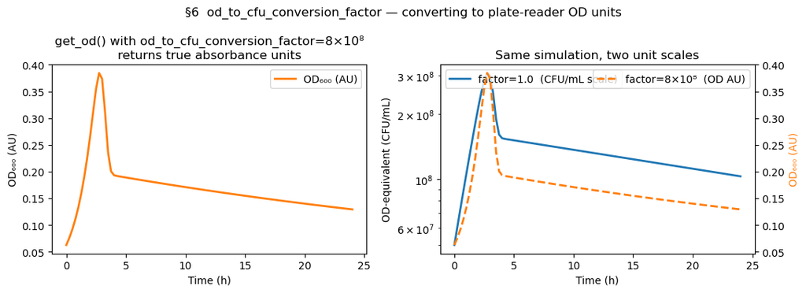

```
Peak OD (AU):   0.384
Peak OD (CFU):  3.08e+08
Ratio:          8.00e+08  (= factor)
```

```python
# ── od_to_cfu_conversion_factor: convert simulation units to true absorbance ──
# Empirical conversion for E. coli at OD₆₀₀: ~8×10⁸ CFU/mL per OD unit.
# With this factor, get_od() returns values in the 0–1 AU range typical of
# a plate-reader trace.
factor = 8e8   # CFU/mL per OD₆₀₀ unit

cfg_od_au = base_od.with_od_debris(u=1.0, v=0.4, kdis=0.02,
                                    od_to_cfu_conversion_factor=factor).build()
res_od_au = solve_ode(PBIModel(cfg_od_au, **IC), t_end=24.0, dt=0.25)

fig, axes = plt.subplots(1, 2, figsize=(11, 4))

axes[0].plot(res_od_au.time, res_od_au.get_od(), "C1-", lw=2, label="OD₆₀₀ (AU)")
axes[0].set(xlabel="Time (h)", ylabel="OD₆₀₀ (AU)",
            title="get_od() with od_to_cfu_conversion_factor=8×10⁸\nreturns true absorbance units")
axes[0].legend()

# Compare: raw (factor=1, CFU scale) vs converted (AU scale)
res_od_raw = solve_ode(PBIModel(base_od.with_od_debris(u=1.0, v=0.4, kdis=0.02).build(), **IC),
                        t_end=24.0, dt=0.25)
axes[1].semilogy(res_od_raw.time, np.maximum(res_od_raw.get_od(), 1),
                 "C0-", lw=2, label="factor=1.0  (CFU/mL scale)")
ax2 = axes[1].twinx()
ax2.plot(res_od_au.time, res_od_au.get_od(), "C1--", lw=2, label="factor=8×10⁸  (OD AU)")
axes[1].set(xlabel="Time (h)", ylabel="OD-equivalent (CFU/mL)")
ax2.set_ylabel("OD₆₀₀ (AU)", color="C1")
axes[1].set_title("Same simulation, two unit scales")
axes[1].legend(loc="upper left")
ax2.legend(loc="upper right")

plt.suptitle("§6  od_to_cfu_conversion_factor — converting to plate-reader OD units")
plt.tight_layout()
plt.show()

print(f"Peak OD (AU):   {res_od_au.get_od().max():.3f}")
print(f"Peak OD (CFU):  {res_od_raw.get_od().max():.2e}")
print(f"Ratio:          {res_od_raw.get_od().max() / res_od_au.get_od().max():.2e}  (= factor)")
```